# Sentiment Analysis : Top 30 Burger Joints in Thailand

Ambareesh Jonnavittula

27/12/2021

# Contents

- Step 1 - Problem Definition
- Step 2 - Environmental Setup
- Step 3 - Data Acquisition
- Step 4 - Data Preparation
- Step 5 - Data Preprocessing
- Step 6 - Data Analysis
- Step 7 - Sentiment Scores & Emotion Classification

# Step 1 - Problem Definition

To identify the top 30 **Burger Joints** among the given tourist accommodations and analyze the sentiment by restaurant and produce an overall emotional feedback for all the burger joints as a whole.

# Step 2 - Environmental Setup

- dplyr : Data manipulations
- tidyverse : Data science tasks
- skimr : Statistical summary
- tm : Text mining
- SnowballC :Text stemming
- wordcloud : Word-cloud generator
- RColorBrewer : colour palettes
- syuzhet : Sentiment analysis
- ggplot2 : Plotting graphs

# Step 3 - Data Acquisition

1. Setup the positive & negative lexicon for Sentiment Analysis
2. Import the Tourist Accommodation reviews file into R
3. Inspect the files

```r
# Step 3 - Data Acquisition
# 3.1 - Setup Lexicon for Sentiment Analysis
p_lex <- read.csv("Sentiment Analysis Data/positive-lexicon.txt")
n_lex <- read.csv("Sentiment Analysis Data/negative-lexicon.txt")

# 3.2 - Import the Tourist Accommodation reviews file into R
df_revs_raw <- read.csv("tourist_accommodation_reviews.csv", header= TRUE)
```

```r
# 3.3 - Inspect lexicon
head(p_lex)
```

```
##           a.
## 1     abound
## 2    abounds
## 3  abundance
## 4   abundant
## 5 accessable
## 6 accessible
```

```r
tail(p_lex)
```

```
##            a.
## 2000      yay
## 2001 youthful
## 2002     zeal
## 2003   zenith
## 2004     zest
## 2005    zippy
```

```r
head(n_lex)
```

```
##     X2.faced
## 1    2-faces
## 2   abnormal
## 3    abolish
## 4 abominable
## 5 abominably
## 6  abominate
```

```r
tail(n_lex)
```

```
##       X2.faced
## 4777    zapped
## 4778      zaps
## 4779    zealot
## 4780   zealous
## 4781 zealously
## 4782    zombie
```

```r
# 3.4 - Inspect the acquired data
names(df_revs_raw)
```

```
## [1] "ID"                    "Review.Date"           "Location"
## [4] "Hotel.Restaurant.name" "Review"
```

```r
head(df_revs_raw)
```

```
##            ID              Review.Date Location         Hotel.Restaurant.name
## 1 rn579778340     Reviewed 1 week ago     Kathu Thong Dee The Kathu Brasserie
## 2 rn576350875    Reviewed 3 weeks ago     Kathu Thong Dee The Kathu Brasserie
## 3 rn574921678    Reviewed 4 weeks ago     Kathu Thong Dee The Kathu Brasserie
## 4 rn572905503 Reviewed April 12, 2018     Kathu Thong Dee The Kathu Brasserie
## 5 rn572364712 Reviewed April 10, 2018     Kathu Thong Dee The Kathu Brasserie
## 6 rn572308369  Reviewed April 9, 2018     Kathu Thong Dee The Kathu Brasserie
##                                                                                                                                                                                                                                                                   Review
## 1                                                                                                                                                       Just been for sunday roast lamb and beef truly excellent,11out of 10\nCoudnt fault it one bit meat was so tender
## 2                      Quietly set off the main road, nice atmosphere. Immaculate and friendly service. But the real reason to go is the food.\nFood of this quality, at this price, is absolutely remarkable. My new fav restaurant in Phuket, and probably beyond.More
## 3            I made a reservation for a birthday two days in advance assuming we would have a quiet table and a nice dinner. Upon arriving, the staff set up a nice table for us and gave us incredible service. It was unlike other cookie-cutter restaurants we...More
## 4         We visit here regularly and never fail to be impressed by the quality and presentation of the food. We have tried many of the dishes from their extensive menu and are always totally satisfied with all they have to offer. The Boss Patrick and their...More
## 5    Visited this wonderful place on my travels and i cannot complain about anything. We where greeted with a warm welcome of smiles and hellos. The food was outstanding and presented so well. I would highly recommend this place and i will be back again. 10...More
## 6 We travel to Phuket every year from Australia and visit Patrick and his lovely wife each time we visit. They are a fantastic team providing delicious food and outstanding service. The entire staff are like a big family. They always greet us as old friends...More
```

```r
tail(df_revs_raw)
```

```
##                ID            Review.Date Location Hotel.Restaurant.name
## 53639 rn163047718 Reviewed June 5, 2013    Patong               Bite in
## 53640 rn162368197 Reviewed May 29, 2013    Patong               Bite in
## 53641 rn161843734 Reviewed May 25, 2013    Patong               Bite in
## 53642 rn161734077 Reviewed May 24, 2013    Patong               Bite in
## 53643 rn161218072 Reviewed May 19, 2013    Patong               Bite in
## 53644 rn161212765 Reviewed May 19, 2013    Patong               Bite in
##                                                                                                                                                                                                                                                                              Review
## 53639                                                                               we came here for lunch with our family.\nRestaurant nice and cozy.\nFood was great and big.\nstaffs are nice as well. Perfect lication in patong Jungcrylon shopping center.Bravo!!Must try!!!!
## 53640 I love this small restaurant, for the great food, and the extreme friendliness of its staff.\nWell located in Jungceylon shopping, we went there during the rain, and enjoy the free internet, good coffee.\nThe Manager & the owner are 2 friendly ladies, who speaks...More
## 53641                  We stopped at this restaurant after shopping at Jung Ceylon. It's close to main "square" of the mall, so you don't need to walk far. Burgers were delicious, but I should say separate word about desserts. I would never expect to have such a tasty...More
## 53642                                                                                                                    Great times ,This is one of the best restaurant in Phuket town. The owners and staffs are very friendly and helpful. Many selections of foods. Great food!
## 53643                 Bite in, it has become my favorite restaurant in Phuket. The food absolutely delicious fresh healthy & yummy I loved it !!. The service is great. Overall good restaurant indeed!\nGo to try! I really recommend this place. I'll definitely come back again.
## 53644         The restaurant put in a good location in Jungcylon department store,Patong Phuket. I went there with my family and I had a very good time. The food was supurb and very outstanding in good quality. The services were given by the trained staffs.I have been...More
```

```r
summary(df_revs_raw)
```

```
##       ID            Review.Date          Location         Hotel.Restaurant.name
##  Length:53644       Length:53644       Length:53644       Length:53644
##  Class :character   Class :character   Class :character   Class :character
##  Mode  :character   Mode  :character   Mode  :character   Mode  :character
##     Review
##  Length:53644
##  Class :character
##  Mode  :character
```

```r
str(df_revs_raw)
```

```
## 'data.frame':    53644 obs. of  5 variables:
##  $ ID                   : chr  "rn579778340" "rn576350875" "rn574921678" "rn572905503" ...
##  $ Review.Date          : chr  "Reviewed 1 week ago " "Reviewed 3 weeks ago " "Reviewed 4 weeks ago " "Reviewed April 12, 2018 " ...
##  $ Location             : chr  " Kathu" " Kathu" " Kathu" " Kathu" ...
##  $ Hotel.Restaurant.name: chr  "Thong Dee The Kathu Brasserie" "Thong Dee The Kathu Brasserie" "Thong Dee The Kathu Brasserie" "Thong Dee The Kathu Brasserie" ...
##  $ Review               : chr  "Just been for sunday roast lamb and beef truly excellent,11out of 10\nCoudnt fault it one bit meat was so tender" "Quietly set off the main road, nice atmosphere. Immaculate and friendly service. But the real reason to go is t"| __truncated__ "I made a reservation …
```

```r
dim(df_revs_raw)
```

```
## [1] 53644     5
```

```r
skim(df_revs_raw)
```

Data summary

| Name | df_revs_raw |
| --- | --- |
| Number of rows | 53644 |
| Number of columns | 5 |
| _______________________ |  |
| Column type frequency: |  |
| character | 5 |
| ________________________ |  |
| Group variables | None |

**Variable type: character**

| skim_variable | n_missing | complete_rate | min | max | empty | n_unique | whitespace |
| --- | --- | --- | --- | --- | --- | --- | --- |
| ID | 0 | 1 | 10 | 11 | 0 | 49944 | 0 |
| Review.Date | 0 | 1 | 15 | 28 | 0 | 2344 | 0 |
| Location | 0 | 1 | 6 | 17 | 0 | 25 | 0 |
| Hotel.Restaurant.name | 0 | 1 | 3 | 61 | 0 | 537 | 0 |
| Review | 0 | 1 | 6 | 4634 | 0 | 49938 | 0 |

# Step 4 - Data Preparation

1. Duplicate (to lowercase) the “review” column - to transform it later
2. Identify the “burger joints” & Filter them out as a subset
3. Inspect the new subset
4. Inspect the review column to validate the search
5. Creating a function for sentimental analysis
6. Creating a function for Word Cloud

```r
# Step 4 - Data Preparation
# 4.1 Duplicate (to lowercase) the "review" column - to transform it later
df_revs_raw$Review_TRF <- tolower(df_revs_raw$Review)

# 4.2 Identify the "burger joints" & Filter them out as a subset
df_revs_raw$Is_Burg_Joint <- grepl(c("burg"), df_revs_raw$Review_TRF)
df_burg <- subset(df_revs_raw, Is_Burg_Joint==TRUE)

# 4.3 - Inspect the new subset
names(df_burg)
```

```
## [1] "ID"                    "Review.Date"           "Location"
## [4] "Hotel.Restaurant.name" "Review"                "Review_TRF"
## [7] "Is_Burg_Joint"
```

```r
head(df_burg)
```

```
##              ID              Review.Date Location  Hotel.Restaurant.name
## 201 rn580748664     Reviewed 4 days ago     Rawai Green Tamarind Kitchen
## 202 rn579783154     Reviewed 1 week ago     Rawai Green Tamarind Kitchen
## 203 rn579651071     Reviewed 1 week ago     Rawai Green Tamarind Kitchen
## 204 rn574834726    Reviewed 4 weeks ago     Rawai Green Tamarind Kitchen
## 205 rn574713927    Reviewed 4 weeks ago     Rawai Green Tamarind Kitchen
## 206 rn573036147 Reviewed April 13, 2018     Rawai Green Tamarind Kitchen
##                                                                                                                                                                                                                                                  Review
## 201          If you want the best burger in Phuket, look no further. Some people will tell you that the best burger is at a resort, or that Hooters does a really good one, or that they know this 5 star restaurant that has an amazing burger,...More
## 202      I have been here a couple of times now,and have had mixed expieriences. I seems to be that it has to be the right person bbq'ing the food! First time the burgers and bacon was made right,but the next time the burger fell apart when...More
## 203                                                                                                           This place is amazing! Burgers are delicious! High recommended! I will come again. When I will be off my diet<f0>
## 204  This is a must when in Phuket. Their burgers rank top worldwide. The service is fast and friendly, food is served fresh hot and fast - very rare for Thailand. They have a great varié of burgers, also other dishes, but why come here for...More
## 205 The reviews speak for themselves. This is mainly the reason we went here and they didn’t disappoint. The burgers are out of this world and cooked in front of you. Very reasonable price for what you get. Only thing I would say is share a...More
## 206                             Fancied a change from Thai food and had been told about this place before. Excellent recommendation, burgers were huge and delicious - our whole group loved the place, some so much they went back a few nights later!
##                                                                                                                                                                                                                                              Review_TRF
## 201          if you want the best burger in phuket, look no further. some people will tell you that the best burger is at a resort, or that hooters does a really good one, or that they know this 5 star restaurant that has an amazing burger,...more
## 202      i have been here a couple of times now,and have had mixed expieriences. i seems to be that it has to be the right person bbq'ing the food! first time the burgers and bacon was made right,but the next time the burger fell apart when...more
## 203                                                                                                           this place is amazing! burgers are delicious! high recommended! i will come again. when i will be off my diet<f0><u+009f><u+0098><u+0084>
## 204  this is a must when in phuket. their burgers rank top worldwide. the service is fast and friendly, food is served fresh hot and fast - very rare for thailand. they have a great varié of burgers, also other dishes, but why come here for...more
## 205 the reviews speak for themselves. this is mainly the reason we went here and they didn’t disappoint. the burgers are out of this world and cooked in front of you. very reasonable price for what you get. only thing i would say is share a...more
## 206                             fancied a change from thai food and had been told about this place before. excellent recommendation, burgers were huge and delicious - our whole group loved the place, some so much they went back a few nights later!
##     Is_Burg_Joint
## 201          TRUE
## 202          TRUE
## 203          TRUE
## 204          TRUE
## 205          TRUE
## 206          TRUE
```

```r
tail(df_burg)
```

```
##                ID                 Review.Date          Location
## 52873 rn515474777   Reviewed August 20, 2017           Mai Khao
## 52970 rn218461525     Reviewed July 30, 2014         Kata Beach
## 53122 rn144830627  Reviewed November 7, 2012   Thalang District
## 53429 rn188960715 Reviewed December 29, 2013        Phuket Town
## 53595 rn242865031  Reviewed December 3, 2014             Patong
## 53641 rn161843734      Reviewed May 25, 2013             Patong
##                  Hotel.Restaurant.name
## 52873 Tropica Restaurant & Beer Garden
## 52970    Mali Seafood Restaurant & Bar
## 53122                            Chaba
## 53429           Pizza Hut - Jungceylon
## 53595                          Bite in
## 53641                          Bite in
##                                                                                                                                                                                                                                                                                              Review
```

[output cut: 20 more lines]

```r
summary(df_burg)
```

```
##       ID            Review.Date          Location         Hotel.Restaurant.name
##  Length:1454        Length:1454        Length:1454        Length:1454
##  Class :character   Class :character   Class :character   Class :character
##  Mode  :character   Mode  :character   Mode  :character   Mode  :character
##     Review           Review_TRF        Is_Burg_Joint
##  Length:1454        Length:1454        Mode:logical
##  Class :character   Class :character   TRUE:1454
##  Mode  :character   Mode  :character
```

```r
str(df_burg)
```

```
## 'data.frame':    1454 obs. of  7 variables:
##  $ ID                   : chr  "rn580748664" "rn579783154" "rn579651071" "rn574834726" ...
##  $ Review.Date          : chr  "Reviewed 4 days ago " "Reviewed 1 week ago " "Reviewed 1 week ago " "Reviewed 4 weeks ago " ...
##  $ Location             : chr  " Rawai" " Rawai" " Rawai" " Rawai" ...
##  $ Hotel.Restaurant.name: chr  "Green Tamarind Kitchen" "Green Tamarind Kitchen" "Green Tamarind Kitchen" "Green Tamarind Kitchen" ...
##  $ Review               : chr  "If you want the best burger in Phuket, look no further. Some people will tell you that the best burger is at a "| __truncated__ "I have been here a couple of times now,and have had mixed expieriences. I seems to be that it has to be the rig"| __truncated__ "This pl…
##  $ Review_TRF           : chr  "if you want the best burger in phuket, look no further. some people will tell you that the best burger is at a "| __truncated__ "i have been here a couple of times now,and have had mixed expieriences. i seems to be that it has to be the rig"| __truncated__ "this pl…
##  $ Is_Burg_Joint        : logi  TRUE TRUE TRUE TRUE TRUE TRUE ...
```

```r
dim(df_burg)
```

```
## [1] 1454    7
```

```r
skim(df_burg)
```

Data summary

| Name | df_burg |
| --- | --- |
| Number of rows | 1454 |
| Number of columns | 7 |
| _______________________ |  |
| Column type frequency: |  |
| character | 6 |
| logical | 1 |
| ________________________ |  |
| Group variables | None |

**Variable type: character**

| skim_variable | n_missing | complete_rate | min | max | empty | n_unique | whitespace |
| --- | --- | --- | --- | --- | --- | --- | --- |
| ID | 0 | 1 | 10 | 11 | 0 | 1398 | 0 |
| Review.Date | 0 | 1 | 19 | 28 | 0 | 774 | 0 |
| Location | 0 | 1 | 6 | 17 | 0 | 22 | 0 |
| Hotel.Restaurant.name | 0 | 1 | 4 | 56 | 0 | 252 | 0 |
| Review | 0 | 1 | 100 | 1102 | 0 | 1398 | 0 |
| Review_TRF | 0 | 1 | 100 | 1102 | 0 | 1398 | 0 |

**Variable type: logical**

| skim_variable | n_missing | complete_rate | mean | count |
| --- | --- | --- | --- | --- |
| Is_Burg_Joint | 0 | 1 | 1 | TRU: 1454 |

```r
# 4.4 - Inspect the review column to validate the search
head(df_burg$Review)
```

```
## [1] "If you want the best burger in Phuket, look no further. Some people will tell you that the best burger is at a resort, or that Hooters does a really good one, or that they know this 5 star restaurant that has an amazing burger,...More"
## [2] "I have been here a couple of times now,and have had mixed expieriences. I seems to be that it has to be the right person bbq'ing the food! First time the burgers and bacon was made right,but the next time the burger fell apart when...More"
## [3] "This place is amazing! Burgers are delicious! High recommended! I will come again. When I will be off my diet<f0>"
## [4] "This is a must when in Phuket. Their burgers rank top worldwide. The service is fast and friendly, food is served fresh hot and fast - very rare for Thailand. They have a great varié of burgers, also other dishes, but why come here for...More"
## [5] "The reviews speak for themselves. This is mainly the reason we went here and they didn’t disappoint. The burgers are out of this world and cooked in front of you. Very reasonable price for what you get. Only thing I would say is share a...More"
## [6] "Fancied a change from Thai food and had been told about this place before. Excellent recommendation, burgers were huge and delicious - our whole group loved the place, some so much they went back a few nights later!"
```

```r
# 4.5 - Creating a function for sentimental analysis
f_sentiment_burg <- function(stem_corpus)
{

  # 4.5.1 - Variable initialization
  tot_pos_cnt <- 0
  tot_neg_cnt <- 0
  pos_cnt_vec <- c()
  neg_cnt_vec <- c()
  size <- length(stem_corpus)

  # 4.5.2 - Loop to identify positive and negative lexicon
  for(i in 1:size)
  {
    # List the words by splitting them by spaces
    corpus_words <- list(strsplit(stem_corpus[[i]]$content, split = " "))

    # Segregate Positive and Negative Counts based on Lexicon
    pos_cnt <-length(intersect(unlist(corpus_words), unlist(p_lex)))
    neg_cnt <-length(intersect(unlist(corpus_words), unlist(n_lex)))

    # Overall positive & negative counts
    tot_pos_cnt <- tot_pos_cnt + pos_cnt
    tot_neg_cnt <- tot_neg_cnt + neg_cnt
  }

  # 4.5.3 - Total Count is the sum of positive & negative counts
  tot_pos_cnt
  tot_neg_cnt
  tot_cnt <- tot_pos_cnt + tot_neg_cnt

  # 4.5.4 - Formulate the Overall Positive % & Overall Negative %
  overall_pos_percent <- (tot_pos_cnt*100)/tot_cnt
  overall_neg_percent <- (tot_neg_cnt*100)/tot_cnt

  overall_pos_percent  # Inspect

  # 4.5.5 - Create a data frame to be utilized at a later stage
  df<-data.frame(Positive=num(tot_pos_cnt),
                 Negative=num(tot_neg_cnt),
                 Total = num(tot_cnt),
                 Overall_Rating = overall_pos_percent)
  return(df)
}

# 4.6 - Creating a function for Word Cloud
f_wc <- function(stem_corpus, v_jt)
{
print(v_jt)
wordcloud(stem_corpus,
          min.freq = 3,
          colors=brewer.pal(8, "Dark2"),
          random.color = TRUE,
          max.words = 100)
}
```

# Step 5 - Data Preprocessing

1. Identify the unique burger joints and sort them by alphabetical order.
2. Variable Initialization
3. Loop using Burger Sentiment function (“f_sentiment_burg()”)
4. Inspect the outcomes for each restaurant
5. Sort by total reviews & pick top 30 restaurants with highest total reviews
6. Setup rownames as Restaurant names
7. Pivot the Positive & Negative reviews for comparative analysis
8. Subset & sort top 30 reviews for Word cloud
9. Loop for Word Clouds (top 30 only)

```r
# Step 5 - Data Preprocessing
# 5.1 - Identify the unique burger joints and sort them by alphabetical order.
v_burgJoints <- sort(unique(df_burg$Hotel.Restaurant.name))
head(v_burgJoints)
```

```
## [1] "2gether Restaurant"                 "360 ° Bar"
## [3] "44 Thaikitchen \"KATA FOOD COURT\"" "9' Sea Breeze"
## [5] "After Beach Bar"                    "Anchor Inn"
```

```r
tail(v_burgJoints)
```

```
## [1] "Wine Connection Deli & Bistro - Central Phuket"
## [2] "Wine Connection Deli & Bistro - Chalong, Phuket"
## [3] "Wine Connection Deli & Bistro - Jungceylon, Patong Beach"
## [4] "YamThai Restaurant"
## [5] "Yorkshire Hotel Restaurant"
## [6] "You and Me Patong"
```

```r
# 5.2 - Variable Initialization
df_final = data.frame( burg_joint=rep(0, 10), Positive=rep(0,10), Negative=rep(0,10), Total=rep(0,10), Overall_Rating=rep(0,10))

iter = 0 # Loop counter variable

# 5.3 - Loop using Burger Sentiment function ("f_sentiment_burg()")
for (burg_joint in v_burgJoints) {

  # 5.3.1 - Loop counter variable
  iter = iter+1

  # 5.3.2 - Create text vectors
  vec_burg_reviews <- subset(df_burg$Review_TRF,df_burg$Hotel.Restaurant.name==burg_joint)

  # gsub() function replaces all matches of a string

  # 5.3.3 - Remove hyperlinks from the reviews (if any)
  vec_burg_reviews <- gsub("http\\S+\\s*", "", vec_burg_reviews)

  # 5.3.4 - Remove punctuation from the reviews
  vec_burg_reviews <- gsub("[[:punct:]]", "", vec_burg_reviews)

  # 5.3.5 - Remove numerical values from the reviews
  vec_burg_reviews <- gsub("[[:digit:]]", "", vec_burg_reviews)

  # 5.3.6 - Remove leading blank spaces at the beginning from the reviews
  vec_burg_reviews <- gsub("^ ", "", vec_burg_reviews)

  # 5.3.7 - Remove blank spaces at the end from the reviews
  vec_burg_reviews <- gsub(" $", "", vec_burg_reviews)

  # 5.3.8 - Replace "\n" word with a space from the reviews
  vec_burg_reviews <- gsub("\n", " ", vec_burg_reviews)

  # 5.3.9 - Replace "<*>" any markup texts with a space from the reviews
  vec_burg_reviews <- gsub("<*>", " ", vec_burg_reviews)

  # 5.3.10 - Converting the text vectors to corpus
  corpus_burg_revs <- Corpus(VectorSource(vec_burg_reviews))

  # 5.3.11 - Clean up corpus by removing stop words and Whitespace
  corpus_burg_revs <- tm_map(corpus_burg_revs, removeWords,stopwords("english"))
  corpus_burg_revs <- tm_map(corpus_burg_revs, stripWhitespace)

  # 5.3.12 - Stem the words to their root of all reviews present in the corpus
  stem_corpus_burg_revs <- tm_map(corpus_burg_revs, stemDocument)

  # 5.3.13 - Utilize the sentiment analysis function for the stemmed corpus and append it to a dataframe
  df_final[iter,] <- c(burg_joint, f_sentiment_burg(stem_corpus_burg_revs))
}

# 5.4 - Inspect the outcomes for each restaurant
head(df_final)
```

```
##                         burg_joint Positive Negative Total Overall_Rating
## 1               2gether Restaurant        3        0     3      100.00000
## 2                        360 ° Bar        2        0     2      100.00000
## 3 44 Thaikitchen "KATA FOOD COURT"        6        2     8       75.00000
## 4                    9' Sea Breeze       88       16   104       84.61538
## 5                  After Beach Bar        3        3     6       50.00000
## 6                       Anchor Inn        1        1     2       50.00000
```

```r
tail(df_final)
```

```
##                                                   burg_joint Positive Negative
## 247           Wine Connection Deli & Bistro - Central Phuket        7        3
## 248          Wine Connection Deli & Bistro - Chalong, Phuket        1        2
## 249 Wine Connection Deli & Bistro - Jungceylon, Patong Beach        2        0
## 250                                       YamThai Restaurant        1        0
## 251                               Yorkshire Hotel Restaurant        8        6
## 252                                        You and Me Patong        1        0
##     Total Overall_Rating
## 247    10       70.00000
## 248     3       33.33333
## 249     2      100.00000
## 250     1      100.00000
## 251    14       57.14286
## 252     1      100.00000
```

```r
names(df_final)
```

```
## [1] "burg_joint"     "Positive"       "Negative"       "Total"
## [5] "Overall_Rating"
```

```r
# 5.5 - Sort by total reviews & pick top 30 restaurants with highest total reviews
df_final <- df_final[order(-df_final$Total),]
df_pop30 <- df_final[1:30,]
head(df_pop30)
```

```
##                  burg_joint Positive Negative Total Overall_Rating
## 141     New York Burger Co.      231       37   268       86.19403
## 113      Le Brooklyn Patong      208       16   224       92.85714
## 30  Burger House Kata Beach      198       23   221       89.59276
## 78   Green Tamarind Kitchen      191       28   219       87.21461
## 69                Flip Side      152       25   177       85.87571
## 216  The Frying Kiwi Eatery      143       25   168       85.11905
```

```r
# 5.6 - Setup rownames as Restaurant names
rownames(df_pop30) <- df_pop30$burg_joint

# 5.7 - Pivot the Positive & Negative reviews for comparative analysis
df_pop30_comp <- df_pop30[,1:3] %>%
  pivot_longer(
    cols = ends_with("tive"),
    names_to = "Review Type",
    values_to = "Review Count",
    values_drop_na = TRUE
  )
head(df_pop30_comp)
```

```
## # A tibble: 6 x 3
##   burg_joint              `Review Type` `Review Count`
##   <chr>                   <chr>                  <dbl>
## 1 New York Burger Co.     Positive                 231
## 2 New York Burger Co.     Negative                  37
## 3 Le Brooklyn Patong      Positive                 208
## 4 Le Brooklyn Patong      Negative                  16
## 5 Burger House Kata Beach Positive                 198
## 6 Burger House Kata Beach Negative                  23
```

```r
tail(df_pop30_comp)
```

```
## # A tibble: 6 x 3
##   burg_joint             `Review Type` `Review Count`
##   <chr>                  <chr>                  <dbl>
## 1 La Boucherie - Chalong Positive                  20
## 2 La Boucherie - Chalong Negative                   4
## 3 Climax on Bangla       Positive                  15
## 4 Climax on Bangla       Negative                   4
## 5 Joe's Downstairs       Positive                  18
## 6 Joe's Downstairs       Negative                   1
```

```r
names(df_pop30_comp)
```

```
## [1] "burg_joint"   "Review Type"  "Review Count"
```

```r
# 5.8 - Subset & sort top 30 reviews for Word cloud
# Subset
df_pop30_revs <- df_burg %>% filter(Hotel.Restaurant.name %in% df_pop30$burg_joint)
dim(df_pop30_revs)
```

```
## [1] 873   7
```

```r
# Sort
v_top30_burg_jts <- sort(unique(df_pop30_revs$Hotel.Restaurant.name))
v_top30_burg_jts
```

```
##  [1] "9' Sea Breeze"
##  [2] "Ann's Kitchen Bar and Grill"
##  [3] "Benny's American Bar & Grill"
##  [4] "Bill Bentley Pub"
##  [5] "Bondi Aussie Bar & Grill Phuket"
##  [6] "Buffalo Steak House - Karon Beach"
##  [7] "Burger House Kata Beach"
##  [8] "Climax on Bangla"
##  [9] "EAT. bar & grill"
## [10] "ELLA Bar & Bistro"
## [11] "Flip Side"
## [12] "Full Moon Brewworks - Microbrewery & Lobs n' Roll"
## [13] "Green Tamarind Kitchen"
## [14] "Grill Bill"
## [15] "Hakan's Bar & Restaurant"
## [16] "Happy Days"
## [17] "i-Kroon Cafe"
## [18] "Joe's Downstairs"
## [19] "La Boucherie - Chalong"
## [20] "Le Brooklyn Patong"
## [21] "Legends Sports Bar & Grill"
## [22] "Lucky 13 Sandwich Patong"
## [23] "New York Burger Co."
## [24] "Nicky's Handlebar"
## [25] "Outdoor Restaurant"
## [26] "Peony Cafe & Restaurant"
## [27] "Rider Cafe"
## [28] "Rustic - Eatery & Bar"
## [29] "The Frying Kiwi Eatery"
## [30] "The Sandwich Club"
```

```
## [1] "9' Sea Breeze"
```

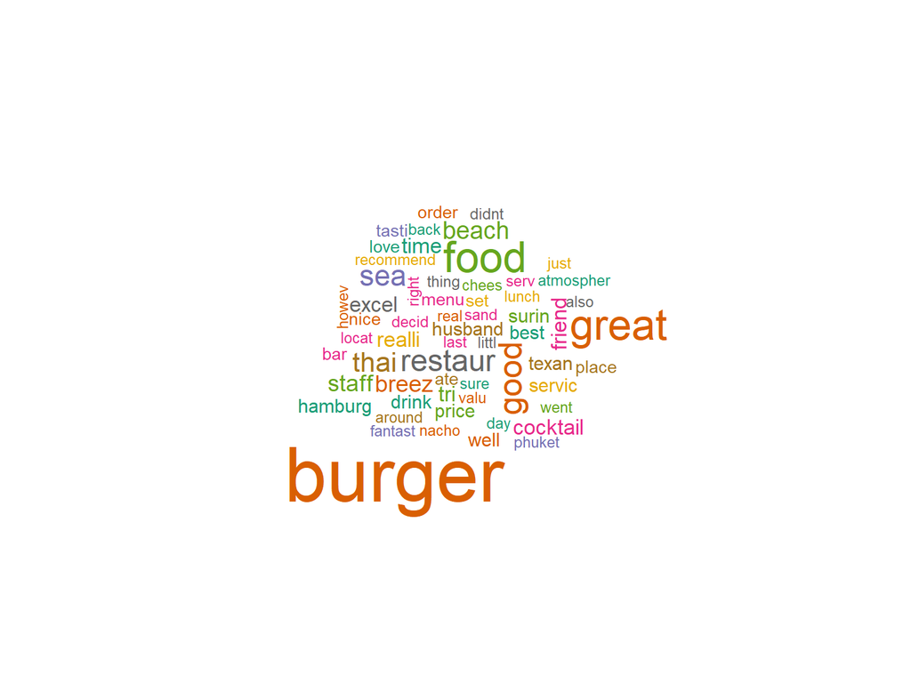

```
## [1] "Ann's Kitchen Bar and Grill"
```

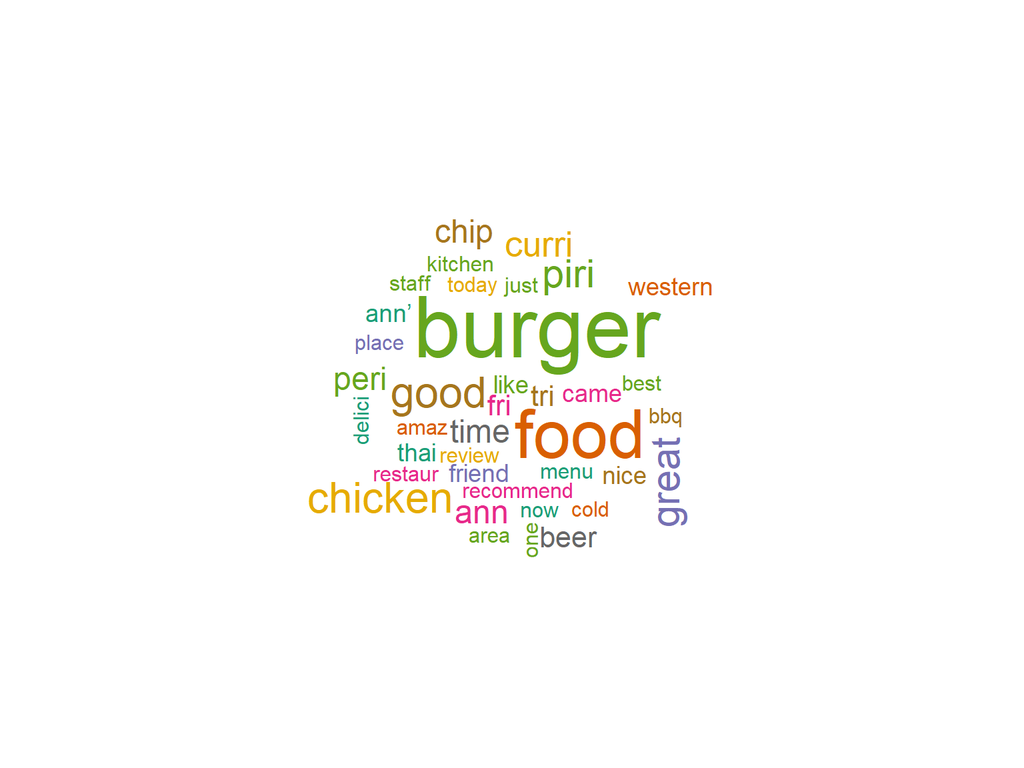

```
## [1] "Benny's American Bar & Grill"
```

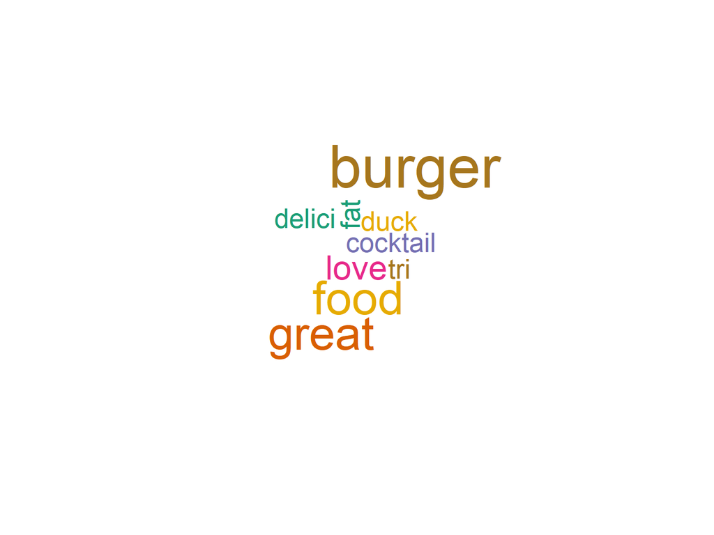

```
## [1] "Bill Bentley Pub"
```

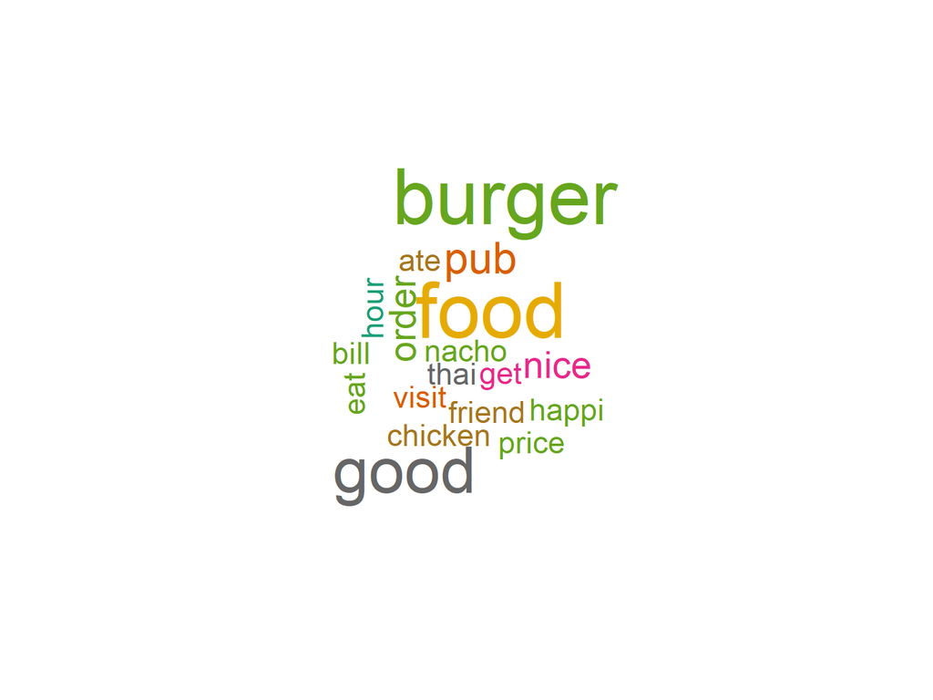

```
## [1] "Bondi Aussie Bar & Grill Phuket"
```

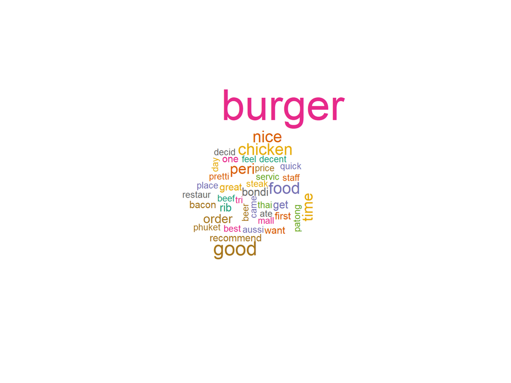

```
## [1] "Buffalo Steak House - Karon Beach"
```

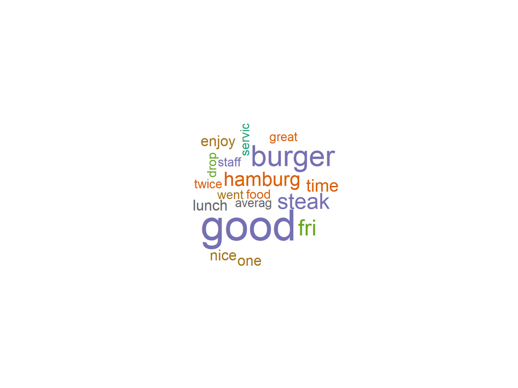

```
## [1] "Burger House Kata Beach"
```

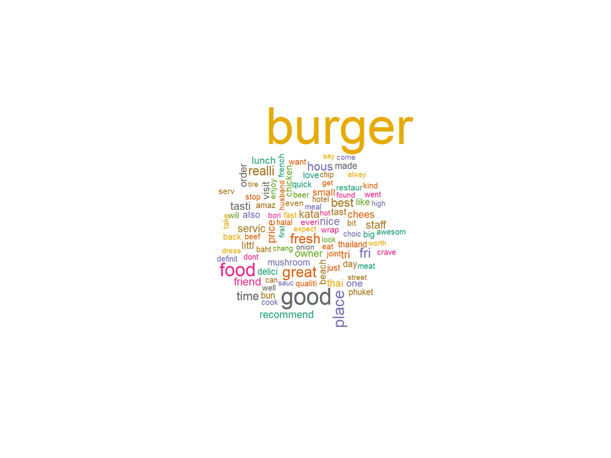

```
## [1] "Climax on Bangla"
```

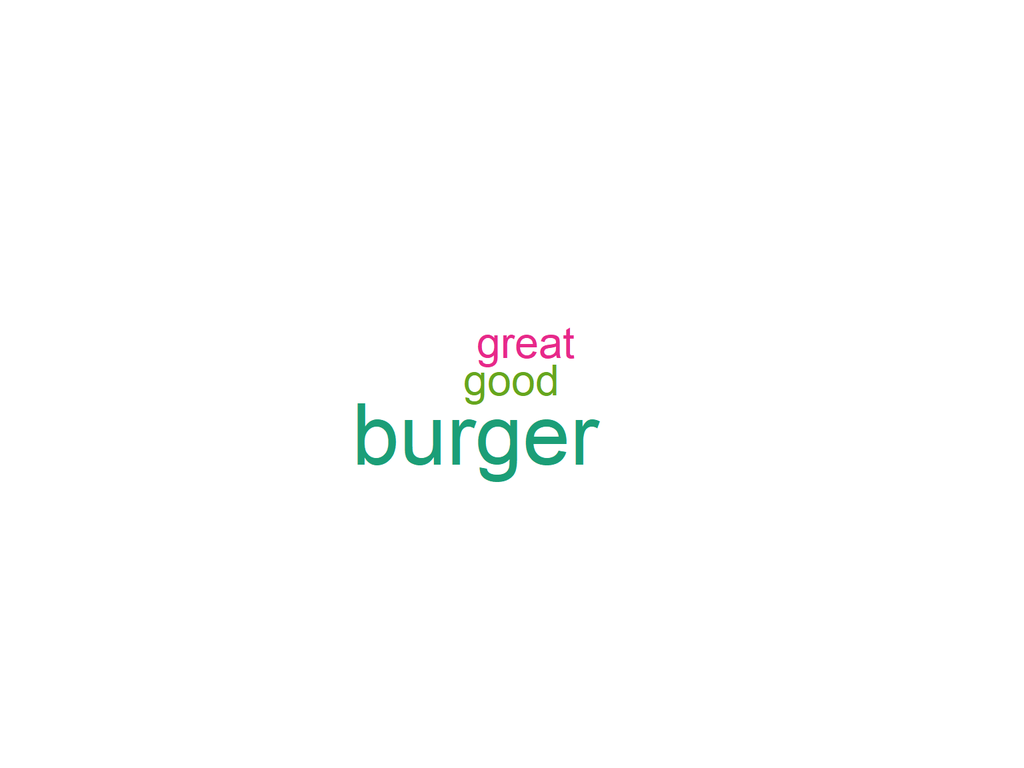

```
## [1] "EAT. bar & grill"
```

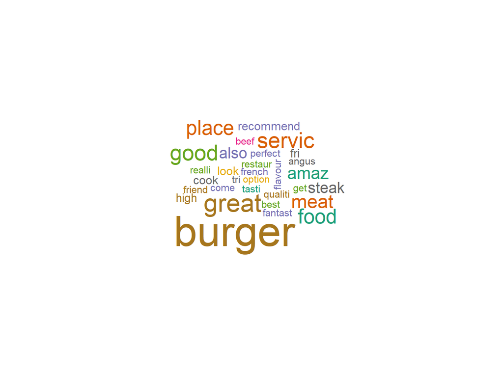

```
## [1] "ELLA Bar & Bistro"
```

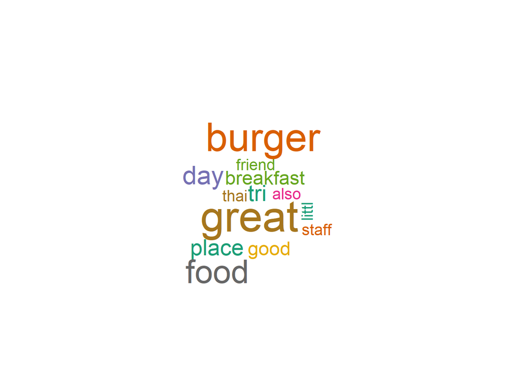

```
## [1] "Flip Side"
```

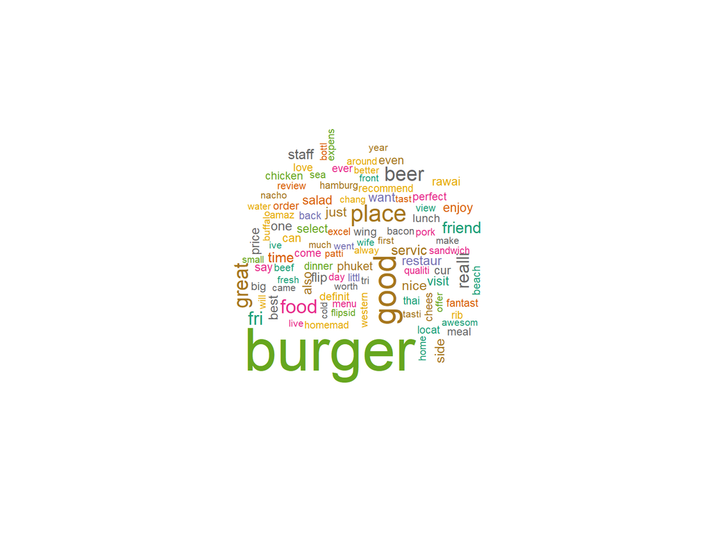

```
## [1] "Full Moon Brewworks - Microbrewery & Lobs n' Roll"
```

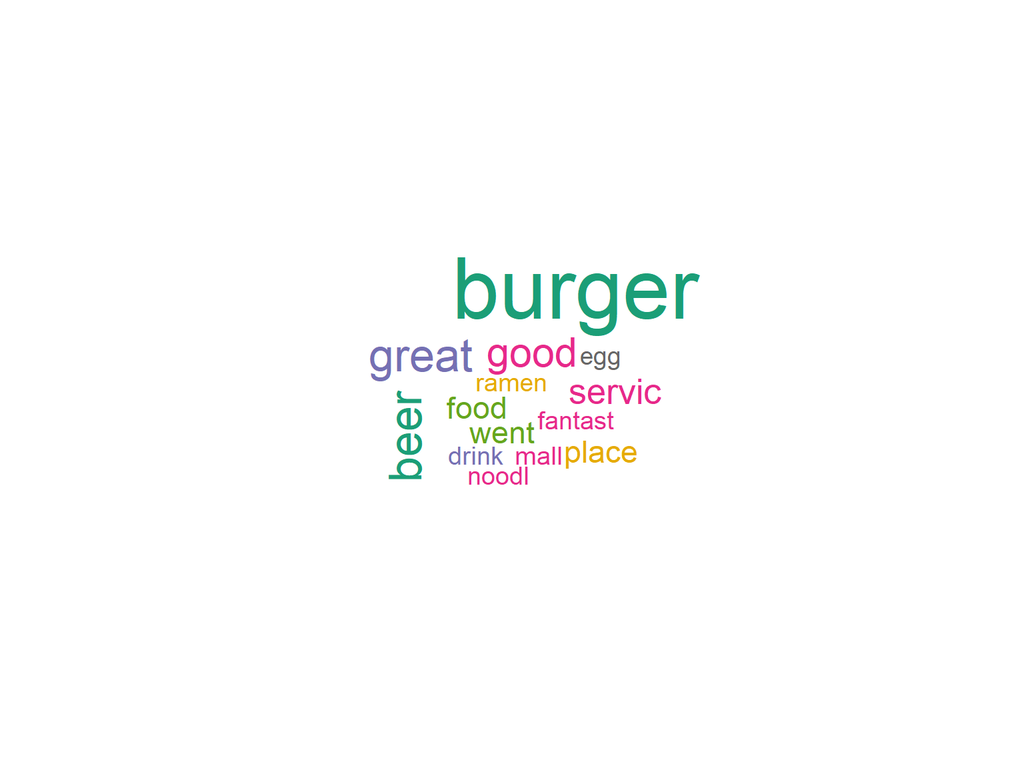

```
## [1] "Green Tamarind Kitchen"
```

[18 more figures not shown]

```r
# 5.9 - Loop for Word Clouds (top 30 only)
for (burg_joint in v_top30_burg_jts) {

  # 5.9.1 - Create text vectors
  vec_burg_reviews <- subset(df_burg$Review_TRF,df_burg$Hotel.Restaurant.name==burg_joint)

  # gsub() function replaces all matches of a string

  # 5.9.2 - Remove hyperlinks from the reviews (if any)
  vec_burg_reviews <- gsub("http\\S+\\s*", "", vec_burg_reviews)

  # 5.9.3 - Remove punctuation from the reviews
  vec_burg_reviews <- gsub("[[:punct:]]", "", vec_burg_reviews)

  # 5.9.4 - Remove numerical values from the reviews
  vec_burg_reviews <- gsub("[[:digit:]]", "", vec_burg_reviews)

  # 5.9.5 - Remove leading blank spaces at the beginning from the reviews
  vec_burg_reviews <- gsub("^ ", "", vec_burg_reviews)

  # 5.9.6 - Remove blank spaces at the end from the reviews
  vec_burg_reviews <- gsub(" $", "", vec_burg_reviews)

  # 5.9.7 - Replace "\n" word with a space from the reviews
  vec_burg_reviews <- gsub("\n", " ", vec_burg_reviews)

  # 5.3.8 - Replace "<*>" any markup texts with a space from the reviews
  vec_burg_reviews <- gsub("<*>", " ", vec_burg_reviews)

  # 5.9.9 - Converting the text vectors to corpus
  corpus_burg_revs <- Corpus(VectorSource(vec_burg_reviews))

  # 5.9.10 - Clean up corpus by removing stop words and Whitespace
  corpus_burg_revs <- tm_map(corpus_burg_revs, removeWords,stopwords("english"))
  corpus_burg_revs <- tm_map(corpus_burg_revs, stripWhitespace)

  # 5.9.11 - Stem the words to their root of all reviews present in the corpus
  stem_corpus_burg_revs <- tm_map(corpus_burg_revs, stemDocument)

  # 5.9.12 - Execute Word Cloud function for the Stem Corpus
  f_wc(stem_corpus_burg_revs, burg_joint)
}
```

```r
# 4.1 - Write to a .csv file
write.xlsx(df_pop30_revs[1:5], "Thai_BurgerJoints.xlsx", row.names=TRUE)
```

# Step 6 - Data Analysis

1. Highest Overall Ratings

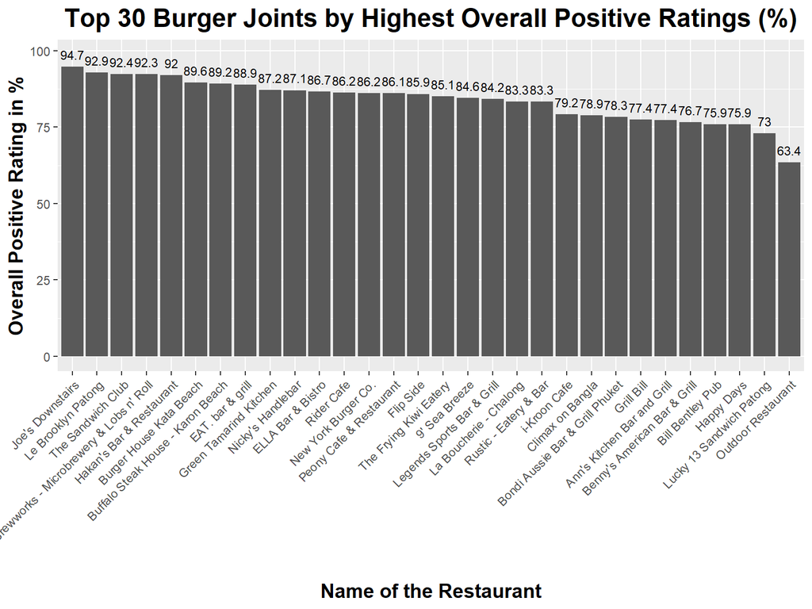

```r
options(digits=2)
df_pop30 %>% mutate(burg_joint = fct_reorder(burg_joint, desc(Overall_Rating))) %>%
  ggplot(aes(burg_joint,Overall_Rating))+
  geom_col() +
  labs(title="Top 30 Burger Joints by Highest Overall Positive Ratings (%)")+
  theme(plot.title = element_text(hjust = 0.5, size = 18, face = 'bold'))+
  xlab("Name of the Restaurant")+
  ylab("Overall Positive Rating in %")+
  theme(axis.title.x = element_text(size=14, face = 'bold'))+
  theme(axis.title.y = element_text(size=14, face = 'bold'))+
  geom_text(aes(label = signif(Overall_Rating, digits = 3)), nudge_y = 4, size = 3)+
  theme(axis.text.x = element_text(angle = 45, vjust = 1, hjust=1))
```

2. Comparative analysis (Positive vs. Negative reviews)

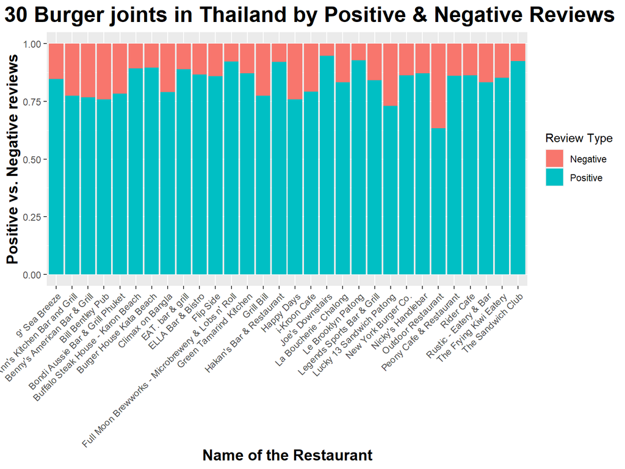

```r
# using 100% stacked bar graph
ggplot(df_pop30_comp,
       aes(fill=df_pop30_comp$`Review Type`,
           y=df_pop30_comp$`Review Count`,
           x=df_pop30_comp$burg_joint)) +
  geom_bar(position="fill", stat="identity") +
  xlab("Name of the Restaurant")+
  ylab("Positive vs. Negative reviews")+
  theme(axis.text.x = element_text(angle = 45, vjust = 1, hjust=1)) +
  ggtitle("Top 30 Burger joints in Thailand by Positive & Negative Reviews") +
  theme(axis.title.x = element_text(size=14, face = 'bold'))+
  theme(axis.title.y = element_text(size=14, face = 'bold'))+
  theme(plot.title = element_text(hjust = 0.5, size = 20, face = 'bold'))+
  guides(fill=guide_legend(title="Review Type"))
```

- However, these overall positive ratings may not fully justify our cause, since the number of ratings also need to be checked first.
3. Total Reviews

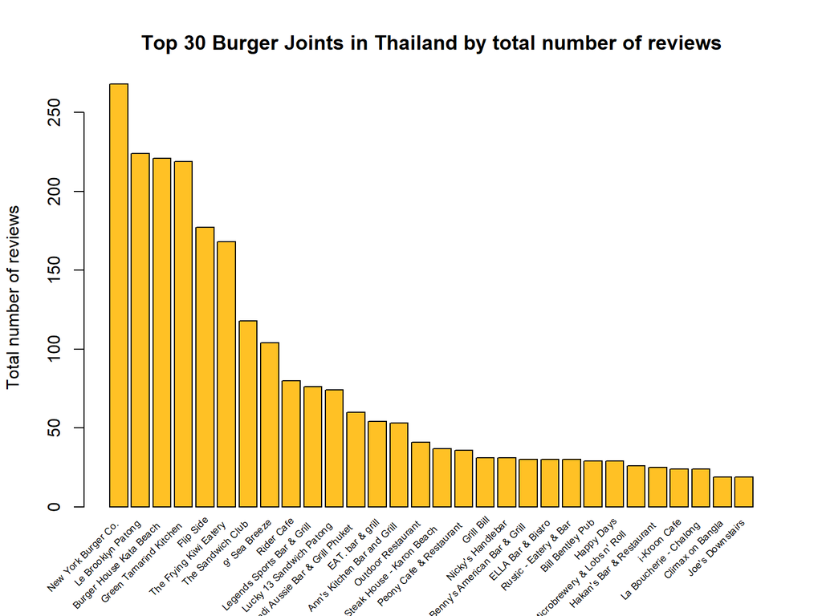

```r
# 6.3.1 - Custom Bar plot (ability to rotate labels)
# Arguments - data - dataframe ; col - column to plot ; lab_vec - Labels vector, aor - Angle of Rotation
custom_x <- function(data, col, lab_vec, aor, title, ylabs) {
  plt <- barplot(data[[col]], main = title, ylab = ylabs, col='goldenrod1', xaxt="n")
  text(plt, par("usr")[3], labels = lab_vec, srt = aor, adj = c(1.1,1.1), xpd = TRUE, cex=0.6)
}

# 6.3.2 - Plotting the top 30 burger joints using number of reviews
custom_x(df_pop30, 'Total', row.names(df_pop30), 45, "Top 30 Burger Joints in Thailand by total number of reviews", "Total number of reviews")
```

4. Comparative analysis for Total Reviews

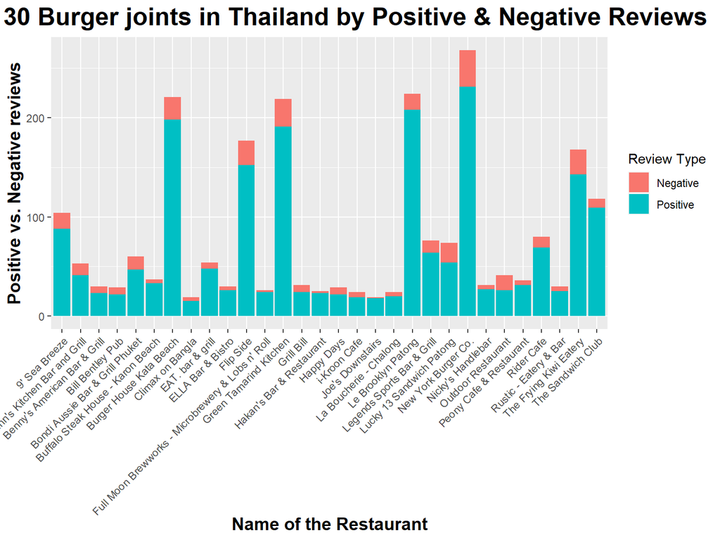

```r
ggplot(df_pop30_comp, aes(fill=df_pop30_comp$`Review Type`,
                          y=df_pop30_comp$`Review Count`,
                          x=df_pop30_comp$burg_joint)) +
  geom_bar(position="stack", stat="identity")+
  xlab("Name of the Restaurant")+
  ylab("Positive vs. Negative reviews")+
  theme(axis.text.x = element_text(angle = 45, vjust = 1, hjust=1)) +
  ggtitle("Top 30 Burger joints in Thailand by Positive & Negative Reviews") +
  theme(axis.title.x = element_text(size=14, face = 'bold'))+
  theme(axis.title.y = element_text(size=14, face = 'bold'))+
  theme(plot.title = element_text(hjust = 0.5, size = 20, face = 'bold'))+
  guides(fill=guide_legend(title="Review Type"))
```

5. Comparison using Combo chart (Bar+Line graph)

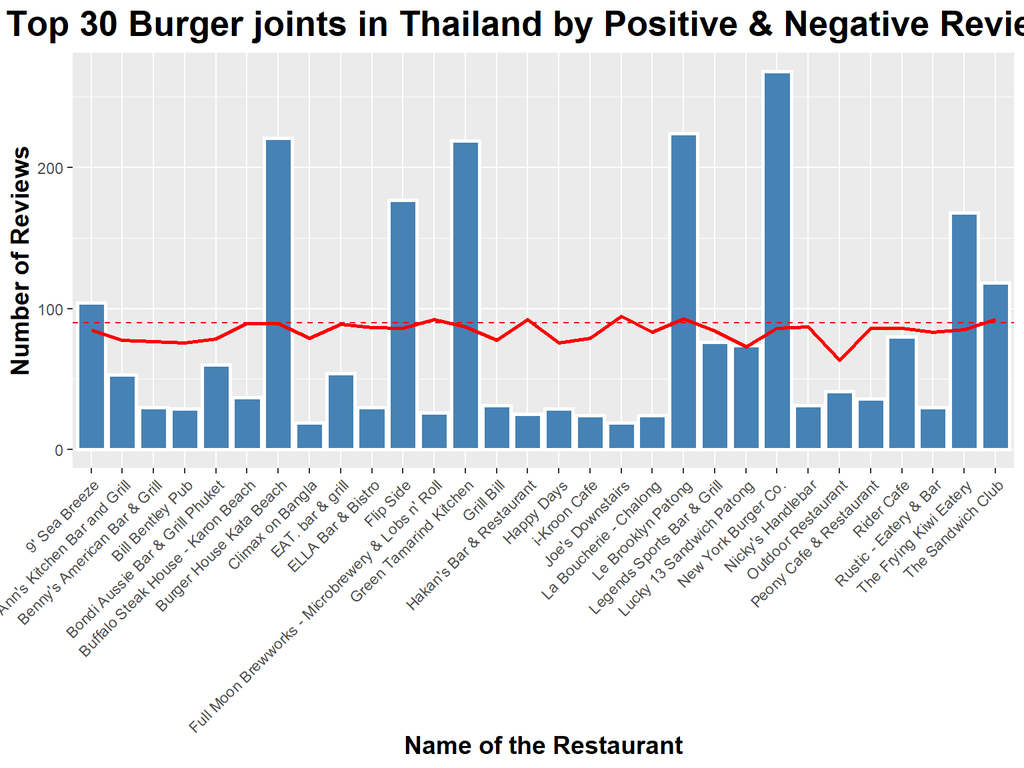

```r
ggplot(df_pop30) +
  geom_col(aes(x = burg_joint, y = Total),
           size = 1, color = "white", fill = "steelblue") +
  geom_line(aes(x = burg_joint, y = Overall_Rating),
            size = 1, color="red", group = 1) +
  xlab("Name of the Restaurant")+
  ylab("Number of Reviews")+
  theme(axis.text.x = element_text(angle = 45, vjust = 1, hjust=1)) +
  ggtitle("Top 30 Burger joints in Thailand by Positive & Negative Reviews") +
  theme(axis.title.x = element_text(size=14, face = 'bold'))+
  theme(axis.title.y = element_text(size=14, face = 'bold'))+
  theme(plot.title = element_text(hjust = 0.5, size = 20, face = 'bold'))+ geom_hline(yintercept=90, linetype="dashed", color = "red")
```

# Step 7 - Overall Sentiment Scores & Emotion Classification

1. Scales to measure sentiment

```r
# 7.1 - Use various methods (scales) to create vectors
# 7.1.1 - Syuzhet
burg_syuzhet <- get_sentiment(df_burg$Review, method="syuzhet")
head(burg_syuzhet)
```

```
## [1] 2.4 0.7 1.2 1.9 0.6 3.2
```

```r
summary(burg_syuzhet)
```

```
##    Min. 1st Qu.  Median    Mean 3rd Qu.    Max.
##    -2.0     1.2     2.1     2.2     3.1     7.8
```

```r
# 7.1.2 - Bing
burg_bing <- get_sentiment(df_burg$Review, method="bing")
head(burg_bing)
```

```
## [1] 3 0 3 6 0 4
```

```r
summary(burg_bing)
```

```
##    Min. 1st Qu.  Median    Mean 3rd Qu.    Max.
##    -4.0     1.0     2.0     2.5     4.0    10.0
```

```r
# 7.1.3 - Affin
burg_afinn <- get_sentiment(df_burg$Review, method="afinn")
head(burg_afinn)
```

```
## [1] 10  0  9  8 -1 10
```

```r
summary(burg_afinn)
```

```
##    Min. 1st Qu.  Median    Mean 3rd Qu.    Max.
##    -8.0     3.0     6.0     6.5     9.0    25.0
```

2. NRC Sentiment Analysis

```r
# 7.2 - NRC Sentiment Analysis
# anger, anticipation, disgust, fear, joy, sadness, surprise, trust
burg_nrc <- get_nrc_sentiment(df_burg$Review)
head(burg_nrc)
```

```
##   anger anticipation disgust fear joy sadness surprise trust negative positive
## 1     0            2       0    0   2       0        1     2        0        2
## 2     0            1       0    0   1       1        0     1        1        1
## 3     0            0       0    0   1       0        0     0        0        1
## 4     1            2       0    0   2       0        0     3        0        3
## 5     1            1       1    0   1       1        0     1        1        2
## 6     0            0       0    1   3       0        0     2        0        3
```

```r
dim(burg_nrc)
```

```
## [1] 1454   10
```

3. Data Transformation for Emotions

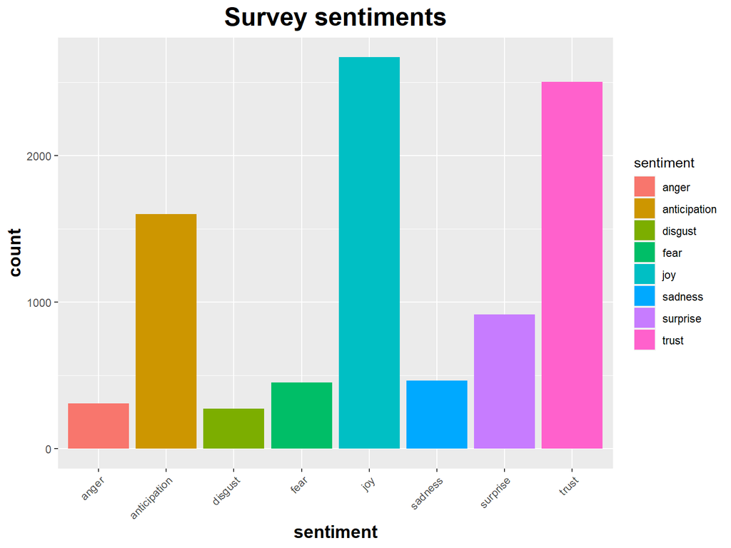

```r
# 7.3.1 - Transpose
burg_nrc_t <- data.frame(t(burg_nrc))

# 7.3.2 - Grouping using Sum
burg_nrc_g <- data.frame(rowSums(burg_nrc_t[1:1454]))

# 7.3.3 - Cleanup
names(burg_nrc_g)[1] <- "count"
burg_nrc_g <- cbind("sentiment" = rownames(burg_nrc_g), burg_nrc_g)
rownames(burg_nrc_g) <- NULL
burg_nrc_final<-burg_nrc_g[1:8,]

# 7.3.4 - Plot using quickplot
#Plot One - count of words associated with each sentiment
quickplot(sentiment, data=burg_nrc_final, weight=count, geom="bar", fill=sentiment, ylab="count")+
  ggtitle("Survey sentiments")+
  theme(axis.text.x = element_text(angle = 45, vjust = 1, hjust=1)) +
  theme(axis.title.x = element_text(size=14, face = 'bold'))+
  theme(axis.title.y = element_text(size=14, face = 'bold'))+
  theme(plot.title = element_text(hjust = 0.5, size = 20, face = 'bold'))
```

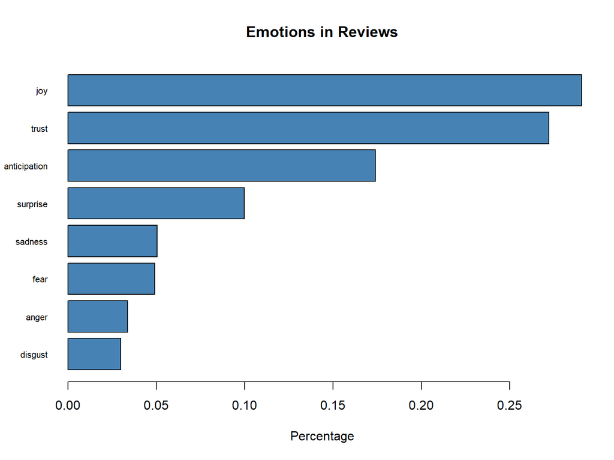

```r
# 7.3.4 - Plot to identify strong vs weak emotions
barplot(
  sort(colSums(prop.table(burg_nrc[, 1:8]))),
  horiz = TRUE,
  cex.names = 0.7,
  col='steelblue',
  las = 1,
  main = "Emotions in Reviews", xlab="Percentage"
)
```